# Part II - Presentation of the Analysis of CoGo Bike Sharing Sytem Data

## by Ahlam Mustapha

## Investigation Overview

> This presentation is about deriving insights from a bicycle sharing platform data. The data contain information about tripduration and other important features that can be investigated for valuable insights. The main insights I will be sharing are detailed in this presentation

## Dataset Overview

> The dataset contains a total of 16,868 bicycle rides from CoGo for the entire year of 2019 with 11 features namely trip_id, start_time, end_time, tripduration, from_station_name, to_station_name, usertype, gender, birthyear, start_date, and end_date.

## Distribution of the Trip Duration of Rides

> The distribution of this variable was heavily skewed due to some outliers. Hence I scaled it using logarithmic scale and it became more normally distributed. It can be seen that most of the trip duration fell between 100 and 1000 seconds while few others fell below and above these values.

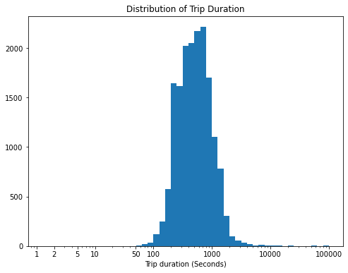

```python
#scaling the distribution of the tripduration feature
bins = 10 ** np.arange(0.1, 5+0.1, 0.1)
ticks = [1, 2, 5, 10, 50, 100, 1000, 10000, 100000]
labels = ['{}'.format(val) for val in ticks]

plt.figure(figsize=[8, 6])
plt.hist(data = godata, x = 'tripduration', bins = bins)
plt.title('Distribution of Trip Duration')
plt.xscale('log')
plt.xticks(ticks, labels)
plt.xlabel('Trip duration (Seconds)');
```

## Most Favourite Station

> I wanted to find out which station among all the start stations was popular and most used. Hence I plotted a bar chart of all stations with the station with the highest frequency count being ranked first in that order till the least used station. Front St & Town St came first with a total frequency of 7.7%.

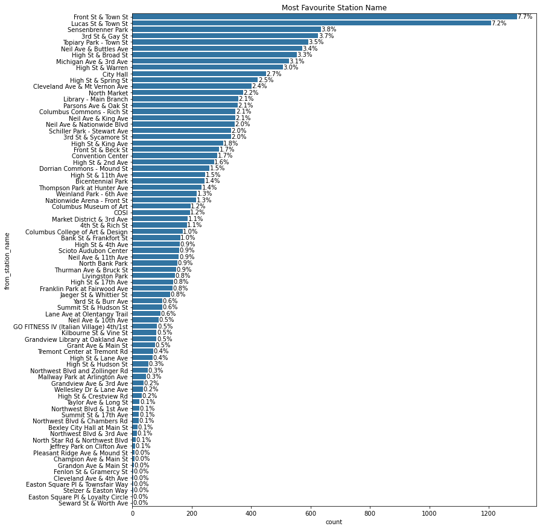

```python
barchartedit('from_station_name', 'color')
```

## Birth Year Vs. Trip Duration

> I wanted to know if there will be any relationship between birth year and trip duration. Upon investigation, I realised that there was no clear relationship between these two variables hence they seemed independent of each other.

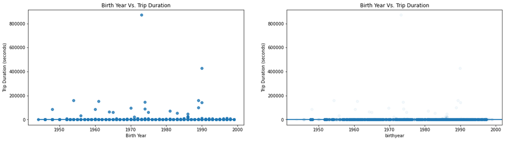

```python
#is there any relationship between the birth year of riders and their trip durations?
# Scatter plot
plt.figure(figsize = [20, 5])
#the first plot shows the scatter plot between birthyear and tripduration
plt.subplot(1, 2, 1)
sb.regplot(data = godata, x = 'birthyear', y = 'tripduration')
plt.title('Birth Year Vs. Trip Duration')
plt.xlabel('Birth Year')
plt.ylabel('Trip Duration (seconds)');

#the second plot shows the same scatter plot but with some transformations using jittering and transparency options
plt.subplot(1, 2, 2)
sb.regplot(data = godata, x = 'birthyear', y = 'tripduration', truncate=False, x_jitter=0.3, scatter_kws={'alpha':1/20})
plt.title('Birth Year Vs. Trip Duration')
plt.ylabel('Trip Duration (seconds)');
```

## Trip Duration by Age and Usertype of Riders

> Adding a third variable to this plot showed some key insight. It can be seen that the 'customer' usertype have low trip durations and their ages are between 20 and 60 years old.

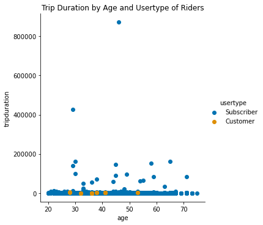

```python
g = sb.FacetGrid(data = godata, hue = 'usertype', height = 5, palette = 'colorblind')
g.map(plt.scatter, 'age', 'tripduration')
plt.title('Trip Duration by Age and Usertype of Riders')
g.add_legend();
```

## Age of Riders across Months and Usertype

> The majority of the 'subscribers' seem to be in their 40's. The larger error bars shows the fewer 'customers' during each month of the year. The majority of the 'customers' seem to be concentrated around May and June and their ages are below 40 years old.

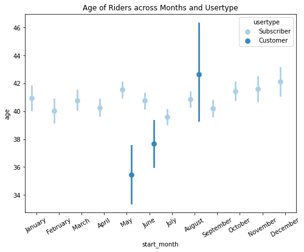

```python
fig = plt.figure(figsize = [8,6])
ax = sb.pointplot(data = godata, x = 'start_month', y = 'age', hue = 'usertype',
           palette = 'Blues', linestyles = '', dodge = 0.4)
plt.title('Age of Riders across Months and Usertype')
plt.xticks(rotation=30)
plt.show();
```

```python
!jupyter nbconvert Part_II_slide_deck.ipynb --to slides --post serve --no-input --no-prompt
```

[output not shown]